# Deep Dive #3

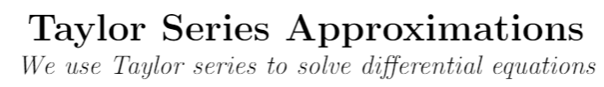

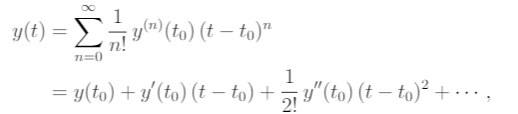

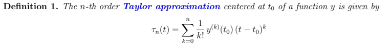

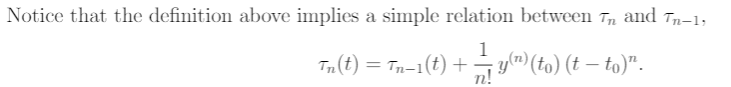

## Question 1

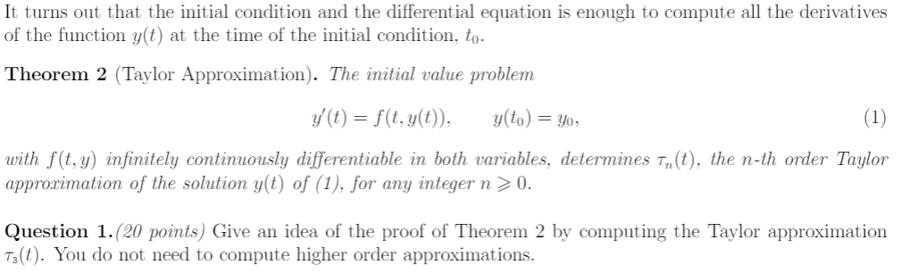

I will simply pull up $\tau_3(t)$

$$ \tau_3(t) = \sum_{k=0}^3 \frac{1}{k!}y^{(k)}(t_0)(t-t_0)^k \\ = y(t_0)+y'(t_0)(t-t_0)+\dfrac{1}{2}y^{(2)}(t_0)(t-t_0)^2 + \dfrac{1}{6}y^{(3)}(t_0)(t-t_0)^3 $$

Since we know $t-0,y(t_0),\text{ and have } y'(t)$, which is infinitely differentiable, we have every value in $\tau_3$ and any $\tau_n$

## Question 2

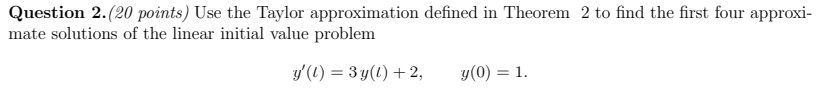

$t_0 = 0, y(t_0) = 1, y'(t) = 3y(t)+2, y''(t)= 3y'(t), \dots $ $$ \tau_0(t) = 1 \\ \tau_1(t) = 1+ (3y(0)+2)(t) = 1+5t \\ \tau_2(t) = 1+ 5t + \frac{1}{2!}3(5)t^2 = 1 + 5t + \frac{15}{2}t^2\\ \tau_3(t) = 1 + 5t + \frac{15}{2}t^2 + \frac{1}{6}3(3(5))t^3 = 1 + 5t + \frac{15}{2}t^2 + \frac{45}{6}t^3 $$

## Question 3

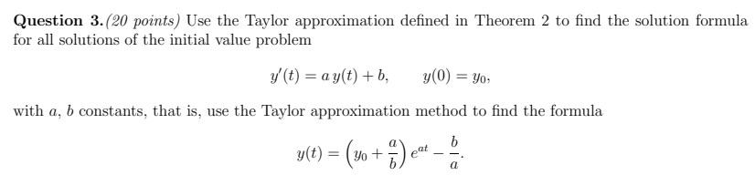

$ \begin{cases} t_0 = 0 \\ y(0) = y_0 \\ y'(0) = ay_0+b \\ y'' = ay'(0) = a(ay_0+b) \\ y^{(3)}=\dots \end{cases} $

Thus $y^{(n)}(0)= (y_0+\frac{b}{a})a^n$ for $n>0$

Remember the taylor expansion for $e^{at}= 1+at+\frac{(at)^2}{2}+\frac{(at)^3}{6}+\dots = \sum_{k=0}^n \frac{(at)^n}{n!}$

$$ \tau_n = \sum_{k=0}^n \frac{1}{k!}y^{(k)}(t_0)(t-t_0)^k \\ = y_0 + \sum_{k=1}^n \frac{1}{k!}(y_0+\frac{b}{a})a^kt^k \\ = y_0 + \sum_{k=1}^n\frac{(at)^k}{k!}(y_0+\frac{b}{a}) $$

To get back to $k=0$ we add back in $\frac{(at)^0}{0!}(y_0+\frac{b}{a}) = y_0+\frac{b}{a}$

$$ = y_0 + \sum_{k=0}^n\frac{(at)^k}{k!}(y_0+\frac{b}{a}) - y_0-\frac{b}{a} \\ = (y_0+\frac{b}{a})\sum_{k=0}^n\frac{(at)^k}{k!} - \frac{b}{a} $$ At $\tau_\infty$ this becomes $$ =(y_0+\frac{b}{a})e^{at}-\frac{b}{a} $$

## Question 4

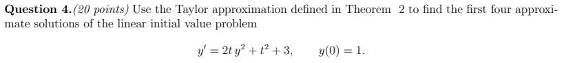

$\begin{cases} t_0=0 \\ y(0)=1 \\ y'(0) = 2(0)(1)^2+(0)^2+3 = 5 \\ y''(t) = 4tyy' + 2y^2+2t+3 \\ y''(0) = 0+2(1)^2+0+3 = 5 \\ y^{(3)}(t)= 4yy'+4t(yy')' + 4yy' + 2 \\ y^{(3)}(0)= 8yy'+2= 8(1)(5)+2=42 \end{cases}$

$$ \tau_0 =1 \\ \tau_1 = 1 + y'(0)t = 1+5t \\ \tau_2 = 1+5t + \frac{5}{2} t^2 \\ \tau_3 = 1+5t + \frac{5}{2} t^2 + \frac{42}{6}t^3 $$

## Question 5

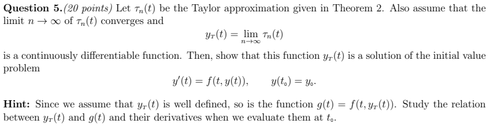

From theorem #2 we know that $\tau_n(t)$ is an approximate solution of $y'(t)=f(t,y(t))$. We're asked to show that $y_T(t)$ is an actual solution.

For $y_T(t_0)$ we have all factors in the summation equal to zero for $k>0$, since it includes the factor $(t-t_0)=0$ for $t=t_0$. Thus $y_T(t_0)=\frac{1}{1}y(t_0)=y_0$

As such $g(t_0)=f(t_0,y_T(t_0))=f(t_0,y(t_0))=y'(t_0)$. However the hint suggests we take the derivative of $y_T(t)$ and $g(t)$ at $t=t_0$.

Since all of these functions are well defined, we know that $$g'(t_0)=f'(t_0,y_T(t_0))=f'(t_0,y(t_0))=y''(t_0)$$ and thus $$g^{[n]}(t_0)=y^{[n+1]}(t_0).$$

As for the derivative of $y_T(t)$, since $\lim_{n\rightarrow\infty} \tau_n(t)$ converges, $y_T(t) $ becomes $$y_T(t)=\lim_{n\rightarrow\infty}\sum_{k=0}^n \frac{1}{k!}y^{(k)}(t_0)(t-t_0)^k=\sum_{k=0}^\infty \frac{1}{k!}y^{(k)}(t_0)(t-t_0)^k$$ and the derivative $y_T'(t)$ becomes $$ y_T'(t) = \sum_{k=0}^\infty \frac{d}{dt}\frac{1}{k!}y^{(k)}(t_0)(t-t_0)^k = \sum_{k=0}^\infty \frac{1}{k!}y^{(k)}(t_0)\frac{d}{dt}(t-t_0)^k\\ = \sum_{k=0}^\infty \frac{1}{k!}y^{(k)}(t_0)k(t-t_0)^{k-1} \\ = \sum_{k=1}^\infty \frac{1}{k-1!}y^{(k)}(t_0)(t-t_0)^{k-1} $$ The $k=0$ becomes zero, allowing us to kick down by k $$=\sum_{k=0}^\infty \frac{1}{k!}y^{(k+1)}(t_0)(t-t_0)^{k} $$

For $t=t_0$ this becomes $$ y_T'(t_0) =\sum_{k=0}^\infty \frac{1}{k!}y^{(k+1)}(t_0)(t_0-t_0)^{k} \\ y_T'(t_0)=y'(t_0) \\ y_T'(t_0)=g(t_0) $$ Thus from the relationship between $g(t_0)$ and $y'(t_0)$, we have $$ y_T^{[n]}(t_0)=y^{[n]}(t_0) $$ for all n.

Considering the fact that $y_T(t_0)$ and all of its derivatives are equal to $y(t_0)$ and its derivatives, all of $y_T(t)$ is defined and is a solution to $y(t)$